# Census Mapping

## Loading in the Choroplethr and choroplethrMaps packages to render maps of the Census data

```r
library(choroplethr)
library(choroplethrMaps)
```

## constructing a map of US states by population

### The state_chropleth function can map any data as long as the function is fed a data frame with two columns with a col named region and a col named value

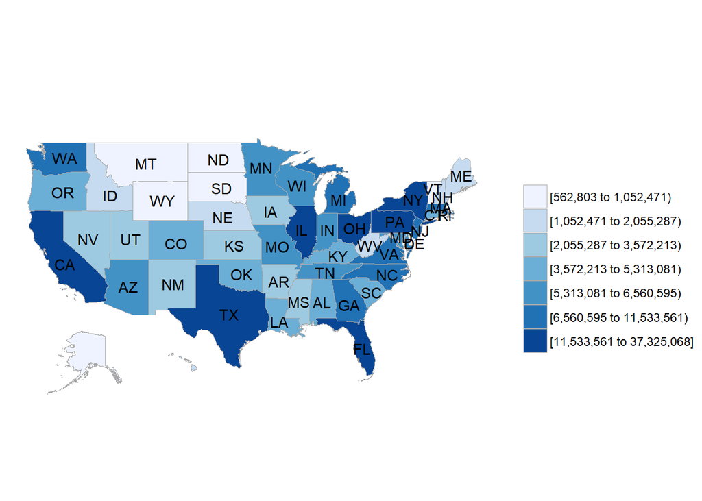

```r
data("df_pop_state")
state_choropleth(df_pop_state)
```

## Customizing the state choropleth map

### Adding a title and legend to the map

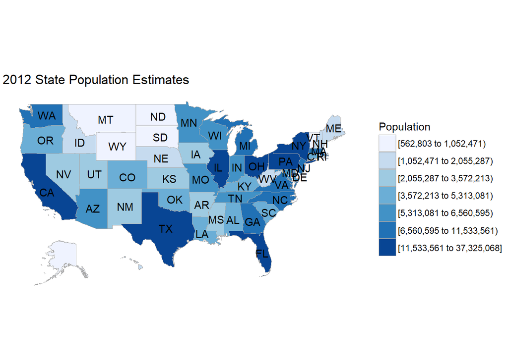

```r
state_choropleth(df_pop_state,
    title = "2012 State Population Estimates",
    legend = "Population")
```

## Creating the same map with a different number of colors

### Looks like choropleth can only handle up to 9 colors

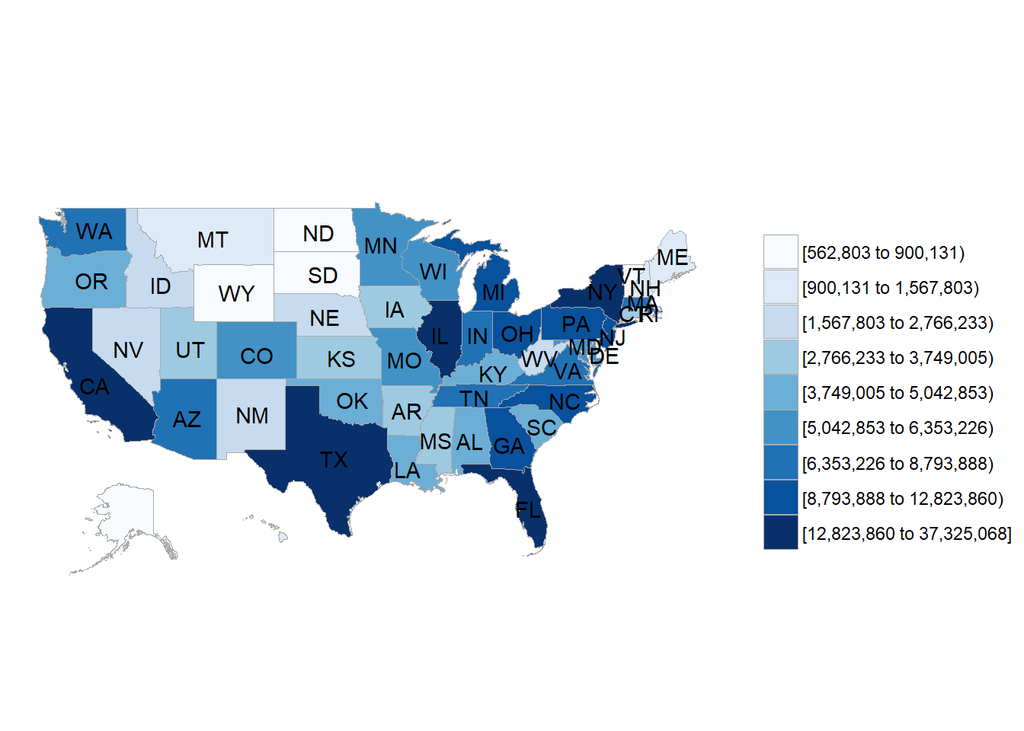

```r
state_choropleth(df_pop_state, num_colors = 9)
```

## Creating a map on a continious scale where outliers will stick out

### This can be done by setting the number of colors to 1

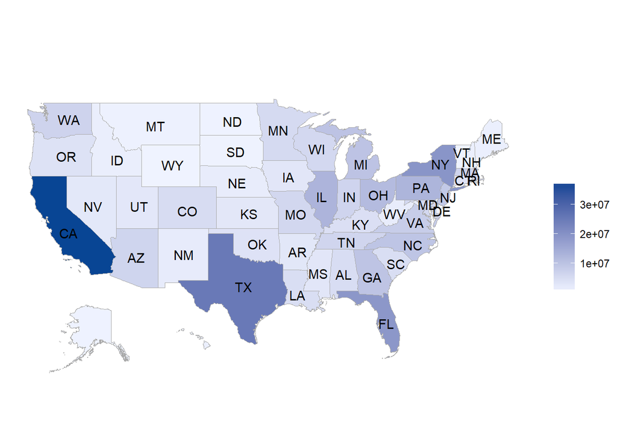

```r
state_choropleth(df_pop_state, num_colors = 1)
```

## Creating a zoomed in map

### You must choose the individual states that you want to use for the visualization

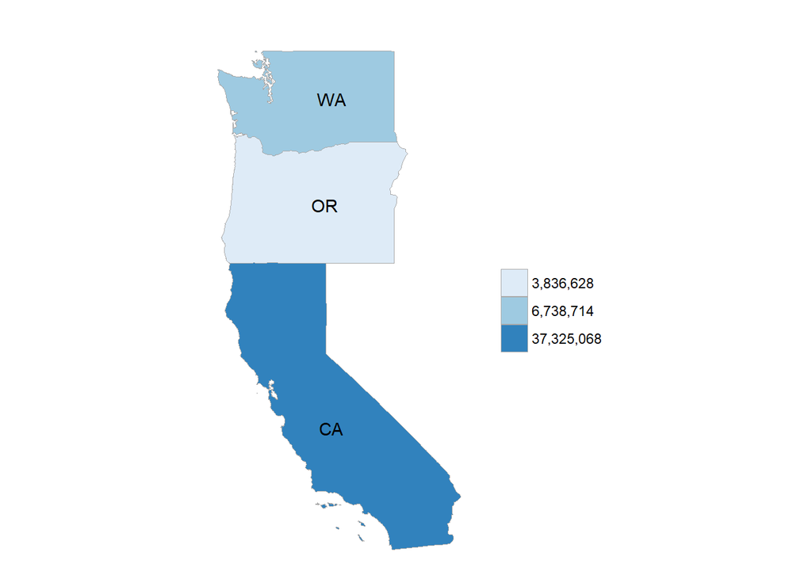

```r
state_choropleth(df_pop_state,
                 zoom = c("california", "oregon", "washington"))
```

### Loading in state demographics data

### opening up the dataframe in the viewer

```r
data(df_state_demographics)
View(df_state_demographics)
```

### Creating the value column needed to map the data into the choropleth function

```r
df_state_demographics$value =
  df_state_demographics$per_capita_income
```

### Mapping the Per Capita Income Estimates

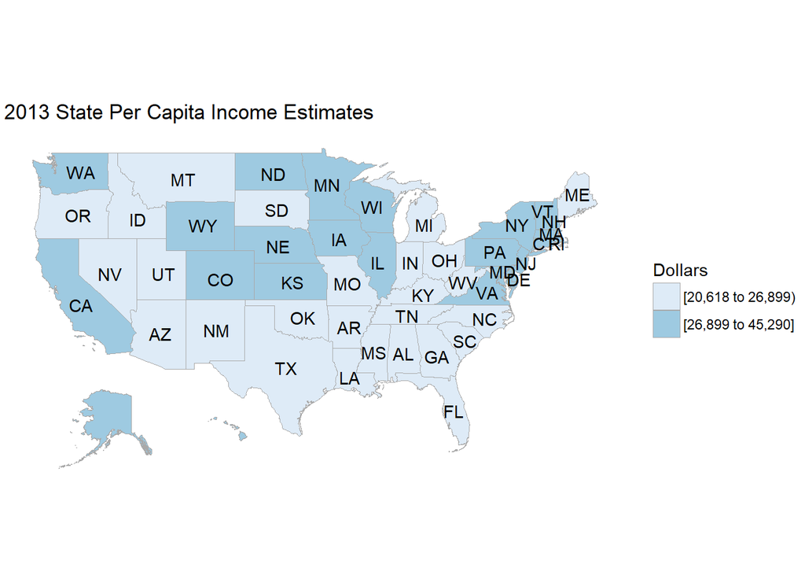

```r
state_choropleth(df_state_demographics,
                 num_colors = 2,
                 title = "2013 State Per Capita Income Estimates",
                 legend = "Dollars")
```

### Using the Census Bureau’s API key to fetch data

```r
df_2010 = get_state_demographics(2010)
View(df_2010)
```

### Creating a Map out of the data we fetched from the Census Bureau (2010 data)

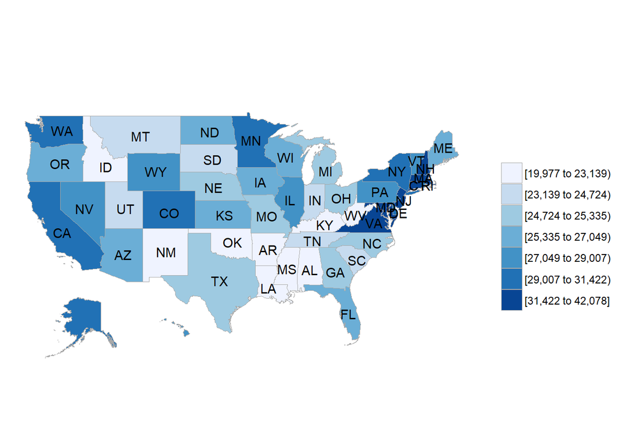

```r
df_2010$value = df_2010$per_capita_income
state_choropleth(df_2010)
```

### Creating a map of 2015 state demographics

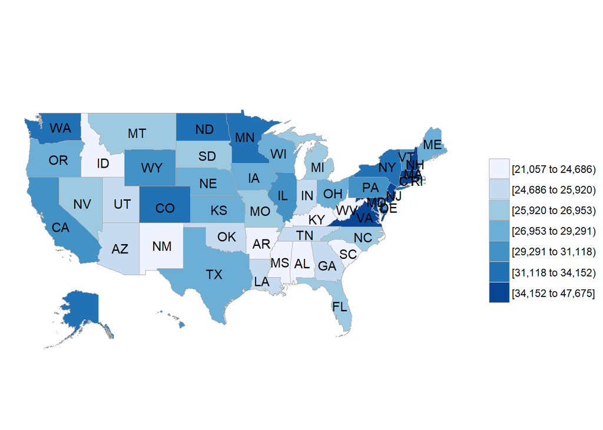

```r
df_2015 = get_state_demographics(2015)
df_2015$value = df_2015$per_capita_income

state_choropleth(df_2015)
```

### Creating a percent change data frame

```r
df_change = calculate_percent_change(df_2010, df_2015)

View(df_change)
```

### Removing unnecessary columns from the percent change data frame

```r
df_change = df_change[, c("region", "value.x","value.y","value")]

View(df_change)
```

### plotting percent change of per capita income

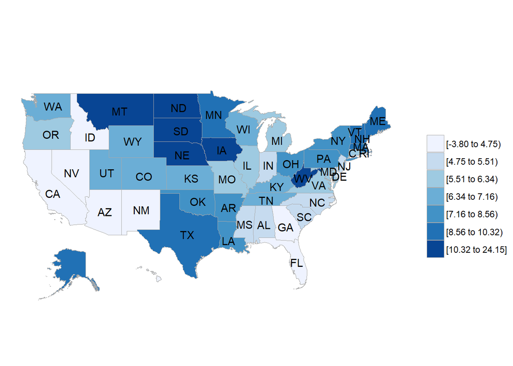

```r
state_choropleth(df_change)
```

### divergent scale for %change

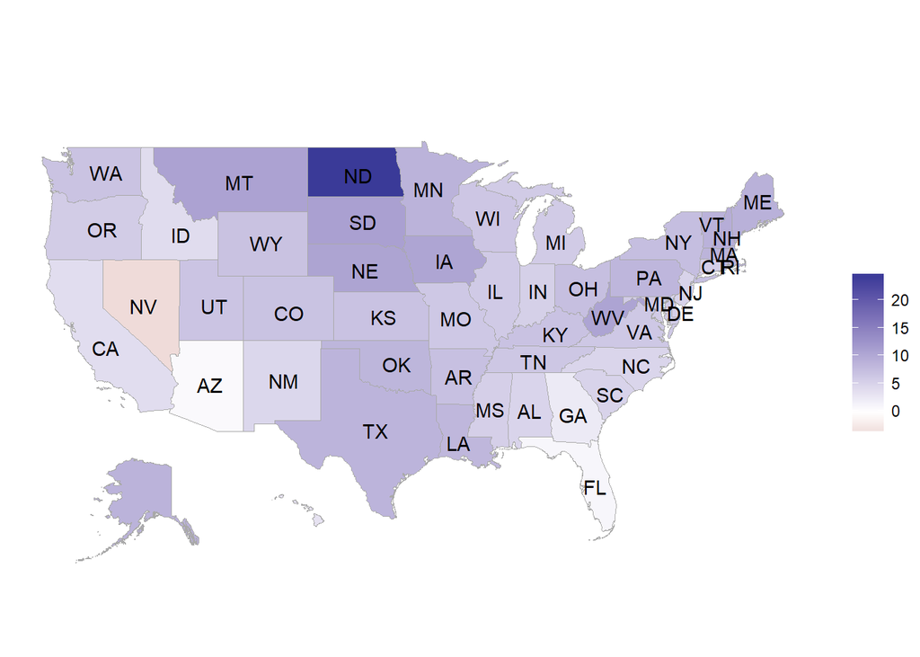

```r
state_choropleth(df_change, num_colors = 0)
```

### Plotting percent change in estimated per-capita income across states

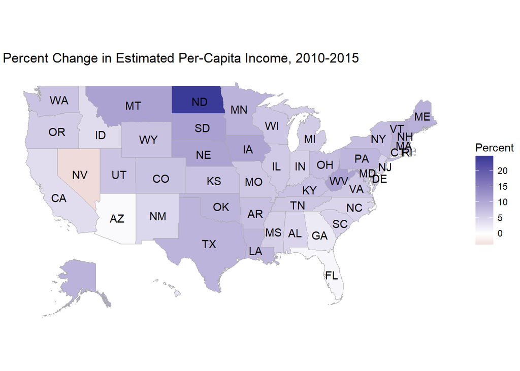

```r
state_choropleth(df_change,
                 num_colors = 0,
                 title = "Percent Change in Estimated Per-Capita Income, 2010-2015",
                 legend = "Percent")
```

### Looking at the get state demographics function

```r
get_state_demographics #
```

```
## function (endyear = 2013, span = 5)
## {
##     state_geo = acs::geo.make(state = "*")
##     race.data = acs::acs.fetch(geography = state_geo, table.number = "B03002",
##         col.names = "pretty", endyear = endyear, span = span)
##     df_race = data.frame(region = as.character(tolower(acs::geography(race.data)$NAME)),
##         total_population = as.numeric(acs::estimate(race.data[,
##             1])), white_alone_not_hispanic = as.numeric(acs::estimate(race.data[,
##             3])), black_alone_not_hispanic = as.numeric(acs::estimate(race.data[,
##             4])), asian_alone_not_hispanic = as.numeric(acs::estimate(race.data[,
##             6])), hispanic_all_races = as.numeric(acs::estimate(race.data[,
##             12])))
##     df_race$region = as.character(df_race$region)
##     df_race$percent_white = round(df_race$white_alone_not_hispanic/df_race$total_population *
##         100)
##     df_race$percent_black = round(df_race$black_alone_not_hispanic/df_race$total_population *
##         100)
##     df_race$percent_asian = round(df_race$asian_alone_not_hispanic/df_race$total_population *
##         100)
##     df_race$percent_hispanic = round(df_race$hispanic_all_races/df_race$total_population *
##         100)
##     df_race = df_race[, c("region", "total_population", "percent_white",
##         "percent_black", "percent_asian", "percent_hispanic")]
##     df_income = choroplethr::get_acs_data("B19301", "state",
##         endyear = endyear, span = span)[[1]]
##     colnames(df_income)[[2]] = "per_capita_income"
##     df_rent = get_acs_data("B25058", "state", endyear = endyear,
##         span = span)[[1]]
##     colnames(df_rent)[[2]] = "median_rent"
##     df_age = get_acs_data("B01002", "state", endyear = endyear,
##         span = span, column_idx = 1)[[1]]
##     colnames(df_age)[[2]] = "median_age"
##     df_demographics = merge(df_race, df_income, all.x = TRUE)
##     df_demographics = merge(df_demographics, df_rent, all.x = TRUE)
##     df_demographics = merge(df_demographics, df_age, all.x = TRUE)
##     data(state.regions, package = "choroplethrMaps", envir = environment())
##     df_demographics = df_demographics[df_demographics$region %in%
##         state.regions$region, ]
##     df_demographics
## }
## <bytecode: 0x000000002c1de6c0>
## <environment: namespace:choroplethr>
```

### Table for per capita income ending in 2015 spanning 5 years

```r
get_acs_data("B19301",
             "state",
             endyear = 2015,
             span = 5)
```

```
## $df
##                  region value
## 1               alabama 24091
## 2                alaska 33413
## 3               arizona 25848
## 4              arkansas 22798
## 5            california 30318
## 6              colorado 32217
## 7           connecticut 38803
## 8              delaware 30554
## 9  district of columbia 47675
## 10              florida 26829
## 11              georgia 25737
## 12               hawaii 29822
## 13                idaho 23399
```

[output cut: 41 more lines]

### plotting acs survey state income

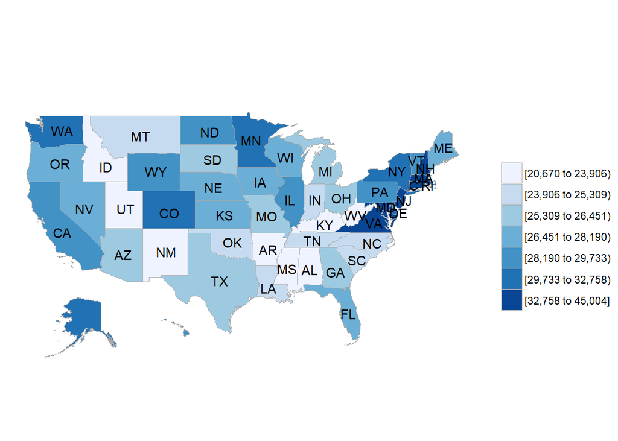

```r
df_income = get_acs_data("B19301", "state")[[1]]
state_choropleth(df_income)
```

### same table including margin of error (90% confidence that the true per capita income is between estimated value + or - margin of error) The ACS survey which is conducted monthly is a sample and thus has a margin of error associated with it.

```r
get_acs_data("B19301",
             "state",
             endyear = 2015,
             span = 5,
             include_moe = TRUE)
```

```
## $df
##                  region value margin.of.error
## 1               alabama 24091             131
## 2                alaska 33413             399
## 3               arizona 25848             123
## 4              arkansas 22798             155
## 5            california 30318              92
## 6              colorado 32217             149
## 7           connecticut 38803             248
## 8              delaware 30554             300
## 9  district of columbia 47675             568
## 10              florida 26829             119
## 11              georgia 25737             123
## 12               hawaii 29822             210
## 13                idaho 23399             238
```

[output cut: 41 more lines]

### US map of counties, shaded by estimated per capita income

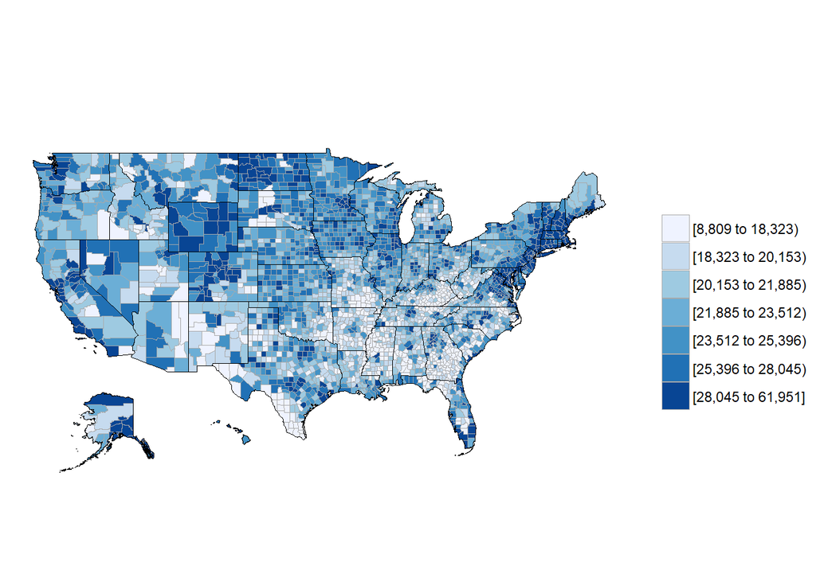

```r
County_Map_df_income <- get_acs_data("B19301", "county")[[1]]
county_choropleth(County_Map_df_income)
```

### Map of Michigan counties, shaded by estimated per capita income

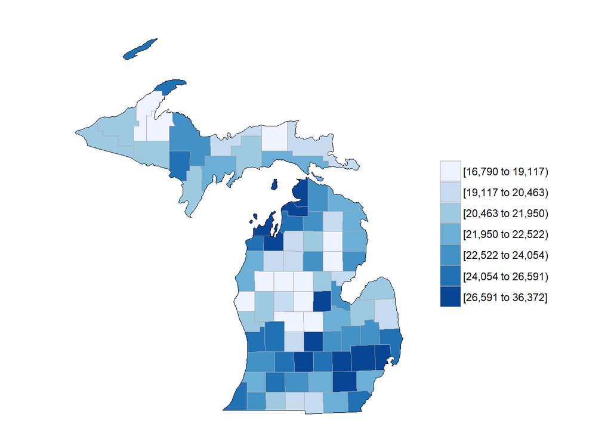

```r
County_Map_df_income <- get_acs_data("B19301", "county")[[1]]
county_choropleth(County_Map_df_income, state_zoom = "michigan")
```

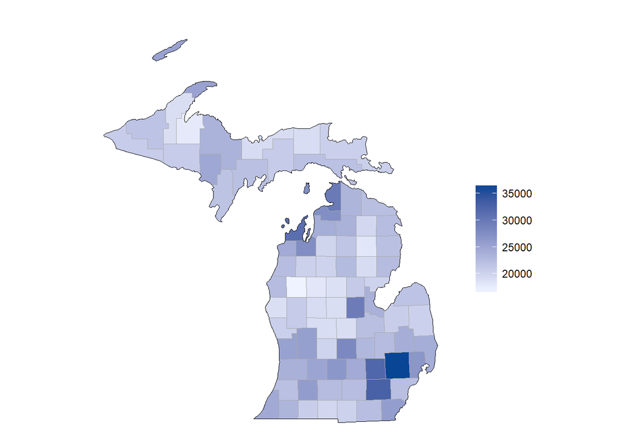

```r
county_choropleth(County_Map_df_income, num_colors = 1, state_zoom = "michigan")
```

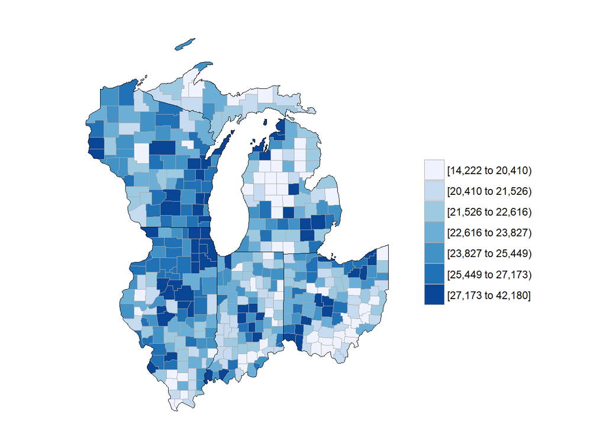

```r
county_choropleth(County_Map_df_income, state_zoom = c("michigan","ohio","illinois","wisconsin","indiana"))
```

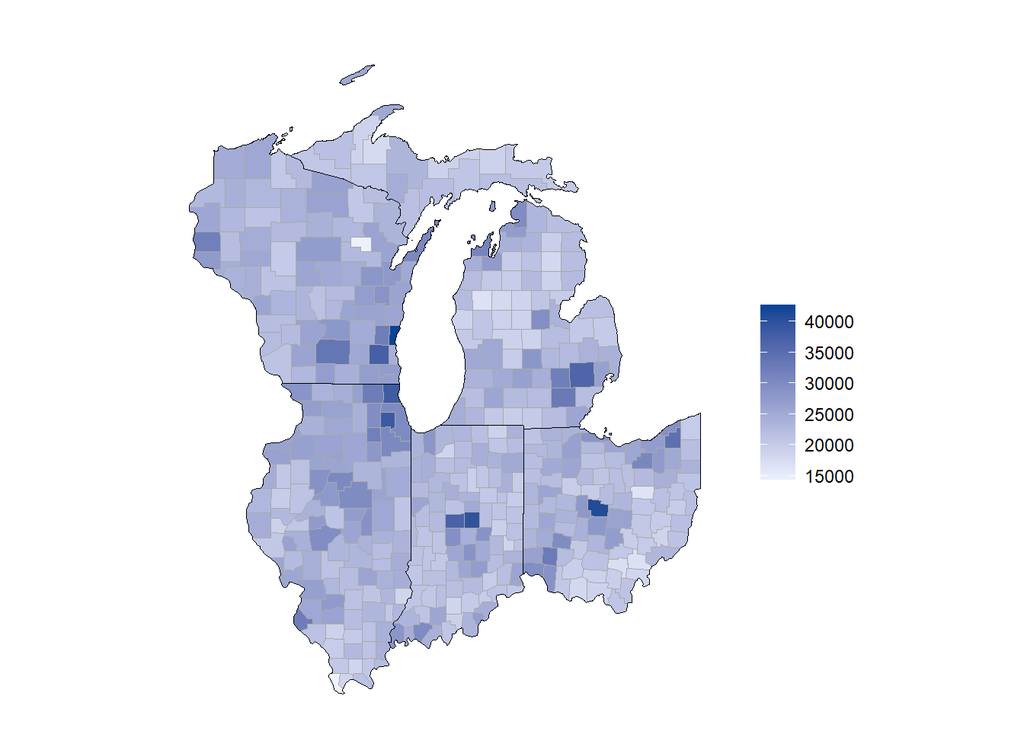

```r
county_choropleth(County_Map_df_income, num_colors = 1, state_zoom = c("michigan","ohio","illinois","wisconsin","indiana"))
```